# Getting started with Kandinsky

# Introduction

**Kandinsky** is an R package for neighbourhood analysis of spatial omics data. Starting from cell or spot coordinates and their associated gene/protein expression, Kandinsky groups cells or spots into **neighbourhoods** (c/s-NBs) and uses this spatial context to:

- describe and cluster cells/spots according to the composition of their neighbourhood
- test for spatial co-localisation or dispersion between cell/spot types
- detect **hot** and **cold** spatial expression areas for any gene, protein, or signature score

This vignette walks through the **core Kandinsky workflow** using a small simulated dataset bundled with the package, so that it can be run quickly on any machine without downloading external data. The toy dataset was generated with SRTsim and mimics a spatial transcriptomics section of the human dorsolateral prefrontal cortex (DLPFC), with spots annotated into 6 cortical layers (`Layer1`-`Layer6`) plus white matter (`WM`).

For more advanced, technology-specific tutorials (CosMx, Xenium, IMC, Visium) that reproduce the analyses of the Kandinsky paper, see the other vignettes.

# Setup

```r
library(Kandinsky)
library(Seurat)
library(dplyr)
library(sf)
library(spdep)
library(ggplot2)
```

# 1) Loading the toy dataset

Kandinsky ships a small simulated dataset, already stored as a `Seurat` object, that can be retrieved with `system.file()`. If Kandinsky needs to call any external Python tool (for instance, some of the optional benchmarking/clustering functions described at the end of this vignette), the path to a compatible Python environment can be set once at the top of the script:

```r
pypath = '/path/to/your/python'
```

We then load the toy dataset:

```r
data = system.file('extdata','SRTsim_simulated_data_Seurat.rds', package = 'Kandinsky')
data = readRDS(data)
data
```

```
#> An object of class Seurat
#> 80 features across 3611 samples within 1 assay
#> Active assay: RNA (80 features, 0 variable features)
#>  1 layer present: counts
#>  1 image present: image
```

The object contains 3611 spots and 80 genes, with a single `RNA` assay. Spot-level metadata stores the spatial `x`/`y` coordinates together with a `label` column reporting the simulated cortical layer of origin:

```r
head(data@meta.data)
```

```
#>                       orig.ident nCount_RNA nFeature_RNA        x        y
#> AAACAAGTATCTCCCA.1 SeuratProject       1204           67 440.6391 381.0981
#> AAACAATCTACTAGCA.1 SeuratProject        206           53 259.6310 126.3276
#> AAACACCAATAACTGC.1 SeuratProject        630           61 183.0783 427.7678
#> AAACAGAGCGACTCCT.1 SeuratProject        927           69 417.2367 186.8137
#> AAACAGCTTTCAGAAG.1 SeuratProject        635           70 152.7003 341.2691
#> AAACAGGGTCTATATT.1 SeuratProject        605           70 164.9415 362.9163
#>                     label               Cell
#> AAACAAGTATCTCCCA.1 Layer3 AAACAAGTATCTCCCA-1
#> AAACAATCTACTAGCA.1 Layer1 AAACAATCTACTAGCA-1
#> AAACACCAATAACTGC.1     WM AAACACCAATAACTGC-1
#> AAACAGAGCGACTCCT.1 Layer3 AAACAGAGCGACTCCT-1
#> AAACAGCTTTCAGAAG.1 Layer5 AAACAGCTTTCAGAAG-1
#> AAACAGGGTCTATATT.1 Layer6 AAACAGGGTCTATATT-1
```

```r
table(data$label)
```

```
#>
#> Layer1 Layer2 Layer3 Layer4 Layer5 Layer6     WM
#>    273    253    989    218    673    692    513
```

# 2) Initializing Kandinsky data

Kandinsky uses spatial coordinates to build cell/spot polygons and to identify neighbourhoods, relying on the `kandinsky_init()` function. Because our toy dataset was not generated by one of the natively-supported platforms (Visium, VisiumHD, CosMx, Xenium, MERSCOPE), we set `tech = 'other'` and manually point Kandinsky to the columns containing spot centroid coordinates using `xcoord_other` and `ycoord_other`.

We define spot neighbourhoods (s-NBs) using the **Delaunay neighbour** method (`nb.method = 'D'`), considering only the sphere of influence (SOI) subgraph (`soi = TRUE`) to limit spurious neighbour links:

```r
data = kandinsky_init(data, tech = 'other', nb.method = 'D', soi = T,
                       xcoord_other = 'x', ycoord_other = 'y')
```

```
#> Building Kandinsky slot "sf"...
#> Building Kandinsky slot "nb"...
#> Building Kandinsky slot "tx"...
#> Building Kandinsky slot "fov_mask"...
#> Kandinsky data loaded into Seurat object!
```

This adds a new `kandata` object to the Seurat `tools` slot, accessible through the `KanData()` accessor:

```r
slotNames(KanData(data))
```

```
#>  [1] "platform"      "nb"            "sf"            "nb.type"
#>  [5] "spot_distance" "texture"       "nnMat"         "tx"
#>  [9] "fov_mask"      "img"           "mask"
```

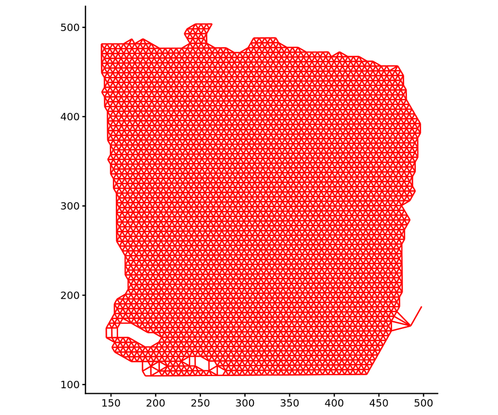

```r
#Visualize lines connecting each spot to its neighbours
nbs=as(spdep::nb2lines(nb=KanData(data,'nb')$neighbours, coords = KanData(data,'sf')$geometry), 'sf')
ggplot()+theme_classic()+geom_sf(data=nbs,color='red')
```

`KanData()` returns:

- `sf`: an `sf` object storing spot geometries (and coordinates)
- `nb`: the sparse neighbour adjacency matrix in a weighted list (listw) format
- `tx`/`img`/`fov_mask`: additional slots populated depending on the technology (empty here, since we used `tech = 'other'`)

We can inspect the neighbourhood network we just built with `nb_summary()`:

```r
nb_summary(data)
```

```
#> Neighbour method: Delaunay triangulation (D), soi = TRUE
#> Total cells/spots: 3611
#> Total neighbour links: 21228
#> Minimum number of neighbours per cell/spot: 1
#> Mean number of neighbours per cell/spot: 5.88
#> Median number of neighbours per cell/spot: 6
#> Max number of neighbours per cell/spot: 7
#> Number of cells/spots with no neighbours: 0
```

# 3) Visualizing the tissue

Kandinsky provides the `KanPlot()` function to map cells/spots into space and colour them according to any metadata column or gene/feature of interest. Let’s visualize the simulated cortical layers:

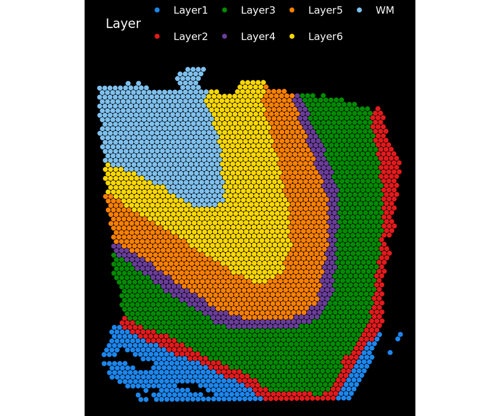

```r
KanPlot(data, feature = 'label',pt.size=2) +
  labs(fill = 'Layer')
```

We can also inspect the distribution of s-NB sizes across spots with `nbSizePlot()`, which is useful when working with distance-based neighbour definitions (`nb.method = 'C'`/`'M'`) that can produce a variable number of neighbours per spot/cell. Since we used a Delaunay definition here, given the regular disposition of Visium spots, most of the spots have 6 neighbours:

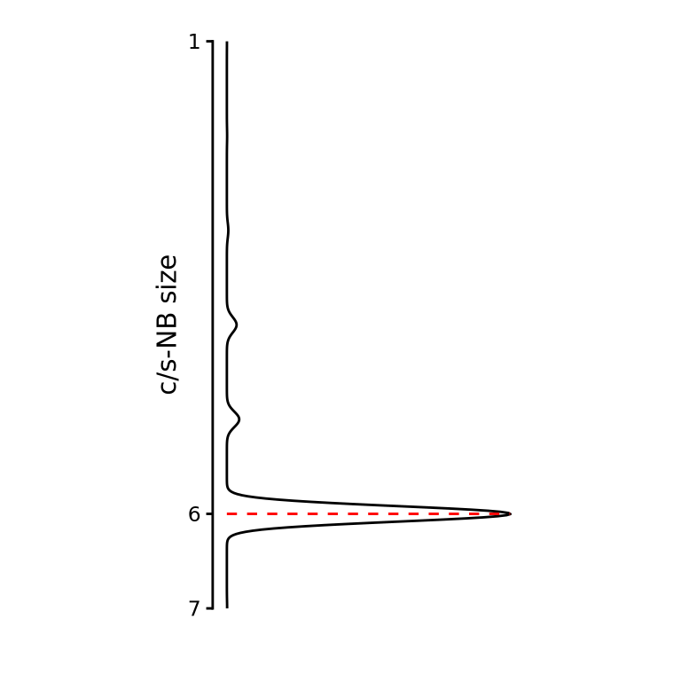

```r
nbSizePlot(data) + theme(aspect.ratio = 2)
```

# 4) Creating tissue region masks

Kandinsky can draw a spatial **mask polygon** around a group of cells/spots sharing the same annotation, using `create_cell_masks()`. Internally, `dbscan` is used to find spatially-dense clusters of the cells/spots of interest, and `concaveman` is then used to trace a concave hull around each cluster.

This is useful, for instance, to outline anatomical regions (e.g. white matter, tumour core, follicles) directly from spot/cell annotations, without needing a separate segmentation mask image. Let’s outline the white matter (`WM`) region of our simulated tissue:

```r
wm_mask = create_cell_masks(data, label = 'label', label_class = 'WM',
                             eps = 30, minPts = 6, concavity = 2,buffer=1)
wm_mask = sf::st_union(wm_mask) #Only needed when multiple masks are generated in different regions
wm_mask
```

```
#> Geometry set for 1 feature
#> Geometry type: POLYGON
#> Dimension:     XY
#> Bounding box:  xmin: 138.3339 ymin: 340.9892 xmax: 286.9136 ymax: 504.8254
#> CRS:           NA
#> POLYGON ((138.3789 470.5587, 138.3789 470.5629,...
```

```r
#Label spots falling within white matter mask using st_contains()
data$within_wm_mask = 'N'
data@meta.data[sf::st_contains(wm_mask,KanData(data,'sf')$geometry) %>% unlist(),]$within_wm_mask = 'Y'
knitr::kable(table(data$within_wm_mask,data$label))
```

|  | Layer1 | Layer2 | Layer3 | Layer4 | Layer5 | Layer6 | WM |
| --- | --- | --- | --- | --- | --- | --- | --- |
| N | 273 | 253 | 989 | 218 | 673 | 692 | 0 |
| Y | 0 | 0 | 0 | 0 | 0 | 0 | 513 |

The output is an `sf` polygon data frame (one row per detected spatial cluster) that can be overlaid on top of a `KanPlot()`:

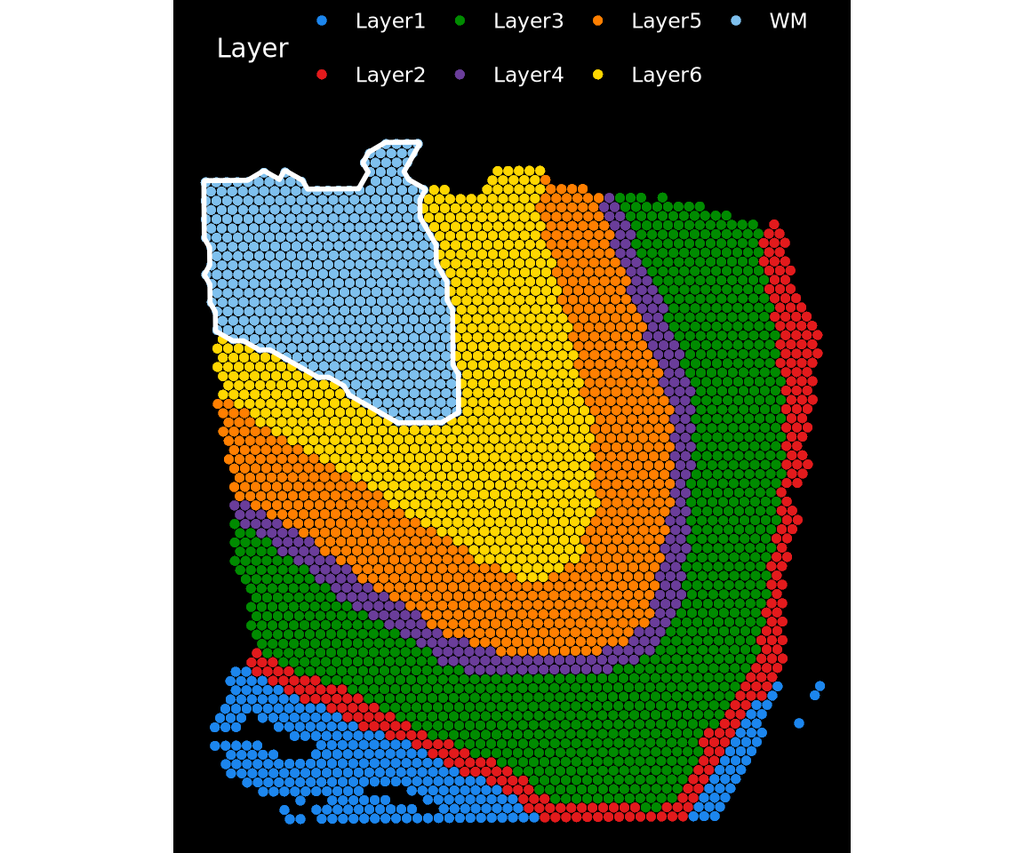

```r
KanPlot(data, feature = 'label',pt.size=2) +
  geom_sf(data = wm_mask, inherit.aes = FALSE, fill = NA, color = 'white', linewidth = 1) +
  labs(fill = 'Layer')
```

Key parameters to tune are `eps`/`minPts` (density-clustering sensitivity, passed to `dbscan::dbscan()`) and `concavity`/`lengthThreshold` (shape detail, passed to `concaveman::concaveman()`); a `buffer` distance can also be added to expand/shrink the resulting mask. When multiple samples are stored in the same object, `sample_key` can be set so that masks are computed independently for each sample.

# 5) Normalizing gene expression

Before any downstream expression-based analysis, we normalize raw counts using the standard Seurat `NormalizeData()` function:

```r
data = NormalizeData(data, verbose = FALSE)
data = UpdateSeuratObject(data)
```

```
#> Validating object structure
#> Updating object slots
#> Ensuring keys are in the proper structure
#> Ensuring keys are in the proper structure
#> Ensuring feature names don't have underscores or pipes
#> Updating slots in RNA
#> Updating slots in image
#> Setting assay used for NormalizeData.RNA to RNA
#> Validating object structure for Assay5 'RNA'
#> Validating object structure for SlideSeq 'image'
#> Object representation is consistent with the most current Seurat version
```

We can now visualize the spatial expression of any gene with `KanPlot()`. Gene `ENSG00000168314` (*MOBP*, a myelin/white-matter marker) is a good example, since it should be enriched in the `WM` region of our simulated tissue:

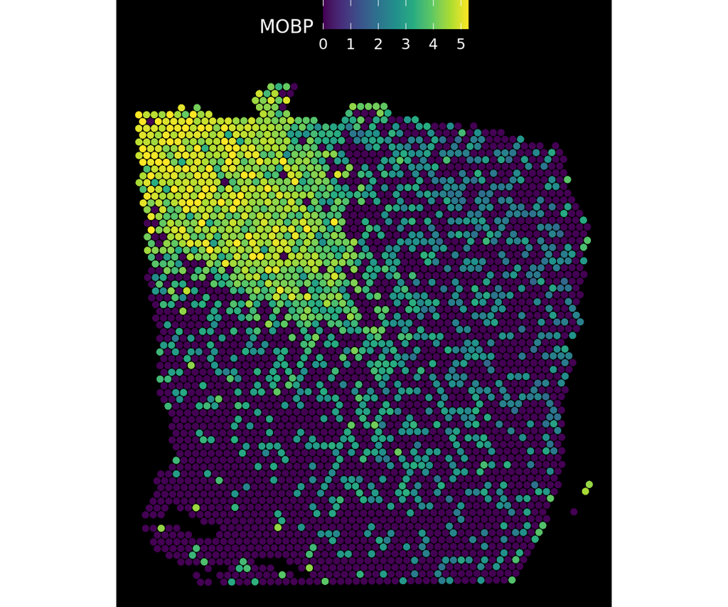

```r
KanPlot(data, feature = 'ENSG00000168314', palette_cont = 'viridis',pt.size=2) +
  labs(fill = 'MOBP')
```

# 6) Neighbourhood composition

The `nnMat()` function summarizes, for every spot, the composition of its s-NB in terms of any categorical annotation - here, the simulated layer of origin (`label`). The resulting matrix is stored in the `nnMat` Kandinsky slot:

```r
data = nnMat(data, label = 'label', return.seurat = TRUE)
```

```
#> Creating neighbour matrix using pre-defined neighbour network
```

```r
knitr::kable(head(KanData(data,'nnMat')$nnMat))
```

|  | Layer1 | Layer2 | Layer3 | Layer4 | Layer5 | Layer6 | WM | tot_nn | label |
| --- | --- | --- | --- | --- | --- | --- | --- | --- | --- |
| AAACAAGTATCTCCCA.1 | 0 | 0 | 6 | 0 | 0 | 0 | 0 | 6 | Layer3 |
| AAACAATCTACTAGCA.1 | 5 | 0 | 0 | 0 | 0 | 0 | 0 | 5 | Layer1 |
| AAACACCAATAACTGC.1 | 0 | 0 | 0 | 0 | 0 | 0 | 6 | 6 | WM |
| AAACAGAGCGACTCCT.1 | 0 | 0 | 6 | 0 | 0 | 0 | 0 | 6 | Layer3 |
| AAACAGCTTTCAGAAG.1 | 0 | 0 | 0 | 0 | 5 | 0 | 0 | 5 | Layer5 |
| AAACAGGGTCTATATT.1 | 0 | 0 | 0 | 0 | 0 | 6 | 0 | 6 | Layer6 |

Each row reports, for a given spot, how many of its neighbours belong to each layer, plus the total number of neighbours (`tot_nn`) and the spot’s own annotation.

This neighbourhood composition matrix can be directly queried using `nn_query()`, which internally relies on `dplyr::filter()`-compatible syntax. For instance, we can flag `Layer6` spots that have at least one `WM` spot in their neighbourhood - i.e. spots close to the layer6/white-matter boundary:

```r
data = nn_query(data,
                 query = "WM >= 1 & label == 'Layer6'",
                 anno_name = 'near_WM')
table(data$near_WM)
```

```
#>
#>    N    Y
#> 3556   55
```

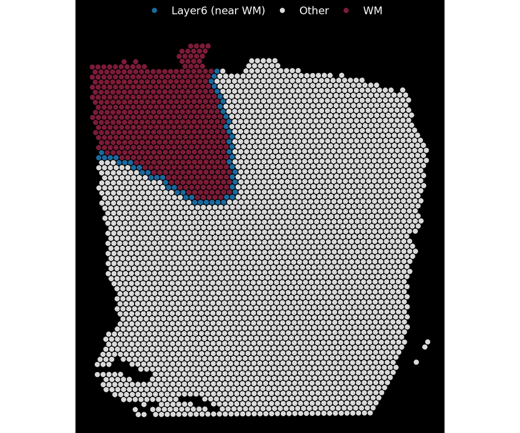

```r
data$boundary_plot = ifelse(data$near_WM == 'Y', 'Layer6 (near WM)',
                             ifelse(data$label == 'WM', 'WM', 'Other'))
KanPlot(data, feature = 'boundary_plot',pt.size=2,
        palette_discrete = c('Other' = 'grey85', 'WM' = '#7B1B38', 'Layer6 (near WM)' = '#1A6AA0')) +
  labs(fill = '')
```

`nn_query()` can be also used to directly perform differential expression analysis between two group of spots/cells with different neighbourhood composition. To do this, `nn_query()` internally call `Seurat::FindMarkers()` function. `label` and `which` arguments define the cell/spot type annotation used to generate the neighbourhood composition matrix and the specific cell/spot type to consider for differential expression analysis, respectively. Additional parameters for `Seurat::FindMarkers()` can also be provided through `nn_query()`.

For instance, we can compare the gene expression profile `Layer6` spots that have at least one `WM` spot in their neighbourhood versus the rest of `Layer6` spots, looking for genes with a |log2 fold-change| higher than log2(1.5):

```r
library(presto) # Speed up differential expression analysis
de = nn_query(data,
                 query = "WM >= 1",
                 anno_name = 'near_WM',
                diffexpr = T,label='label',which = 'Layer6',logfc.threshold = log2(1.5))
```

```
#> Differential expression between 55 near_WM-Y and 637 near_WM-N cells
```

```r
knitr::kable(head(de))
```

|  | p_val | avg_log2FC | pct.1 | pct.2 | p_val_adj |
| --- | --- | --- | --- | --- | --- |
| ENSG00000197971 | 0 | 1.607163 | 1.000 | 0.981 | 0 |
| ENSG00000131095 | 0 | 1.651362 | 1.000 | 0.826 | 0 |
| ENSG00000173786 | 0 | 1.658929 | 0.982 | 0.739 | 0 |
| ENSG00000123560 | 0 | 1.361294 | 1.000 | 0.926 | 0 |
| ENSG00000109846 | 0 | 1.422594 | 1.000 | 0.799 | 0 |
| ENSG00000107317 | 0 | 1.062969 | 1.000 | 0.943 | 0 |

The same neighbourhood composition matrix underlies Kandinsky’s unsupervised neighbourhood-based clustering, described next.

# 7) Neighbourhood-based clustering

Once a neighbourhood composition matrix has been built with `nnMat()`, Kandinsky can group spots/cells into **c/s-NBs-based clusters** according to the similarity of their neighbourhood composition. The default method, `nbCluster()`, relies on model-based clustering (R package `mclust`); the argument `n_clust` accepts a vector of candidate cluster numbers, and the optimal one is selected via the Bayesian information criterion (BIC):

```r
data = nbCluster(data, n_clust = 3:9)
```

[output not shown]

```r
table(data$nbClust.D_soiTRUE)
```

```
#>
#>   1   2   3   4   5   6   7   8   9
#> 602 585 202 280 253 144 493 887 165
```

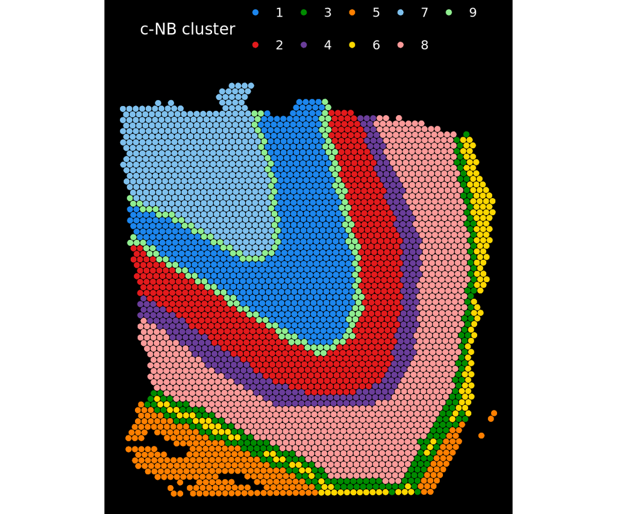

```r
KanPlot(data, feature = 'nbClust.D_soiTRUE',pt.size=2) + labs(fill = 'c-NB cluster')
```

## Alternative clustering methods

```r
data = kmeans_clust(data, n_clust = 3:9, label = 'label')
```

```
#> Creating neighbour matrix using pre-defined neighbour network
#> Optimal number of clusters: 7
```

```r
table(data$kmeans_clusters)
```

```
#>
#>    1    2    3    4    5    6    7
#>  846  147  608 1457  182  232  139
```

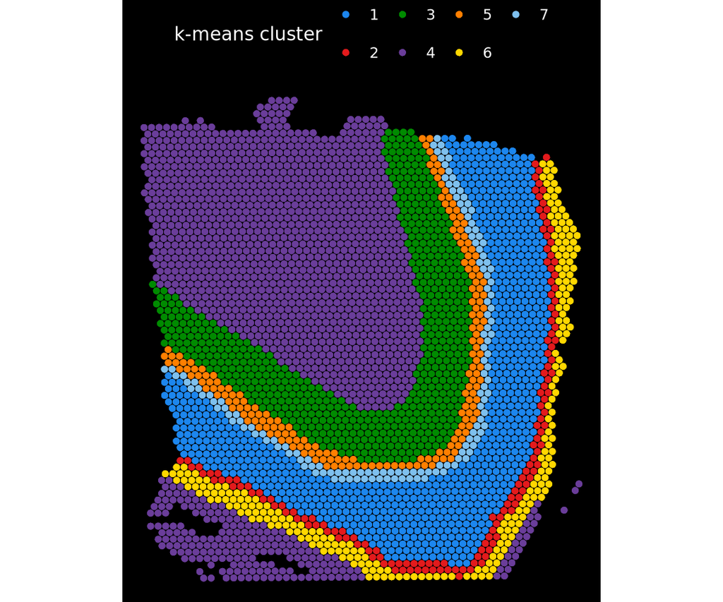

```r
data$kmeans_clusters = as.character(data$kmeans_clusters)
KanPlot(data, feature = 'kmeans_clusters',pt.size=2) + labs(fill = 'k-means cluster')
```

We can quantify the agreement between the two clustering strategies using the adjusted Rand index (ARI, via `mclust::adjustedRandIndex()`):

```r
data$nbClust.D_soiTRUE = as.character(data$nbClust.D_soiTRUE)
mclust::adjustedRandIndex(data$nbClust.D_soiTRUE, data$kmeans_clusters)
```

```
#> [1] 0.6143368
```

Other alternative neighbourhood-clustering wrappers are available for users who want to benchmark Kandinsky against external tools, including `spatopic_clust()` (SpaTopic), `hoodscanR_clust()` (hoodscanR) and `giotto_clust()` (Giotto) - all pure-R/Bioconductor based - as well as `cellcharter_clust()`, `spatialleiden_clust()` and `mesa_clust()`, which call Python-based tools (CellCharter, SpatialLeiden, MESA respectively) through `reticulate`. The latter require a Python environment with the relevant dependencies installed, pointed to via their `python_path` argument (this is what the `pypath` variable defined at the top of this vignette is for):

```r
# Requires a python environment with CellCharter/squidpy/scanpy/scvi installed (see pypath above)
data = cellcharter_clust(data,n_clust = 3:9,mode = 'rna', python_path = pypath)
```

```
#> Initializing CellCharter with reticulate
#> Loading CellCharter and its dependencies...
#> Converting Seurat object to anndata...
#> Running CellCharter...
#> Iteration 1/10
#> Iteration 2/10
#> Iteration 3/10
#> Iteration 4/10
#> Iteration 5/10
#> Iteration 6/10
#> Iteration 7/10
#> Iteration 8/10
#> Iteration 9/10
#> Iteration 10/10
#> Optimal number of clusters: 5
```

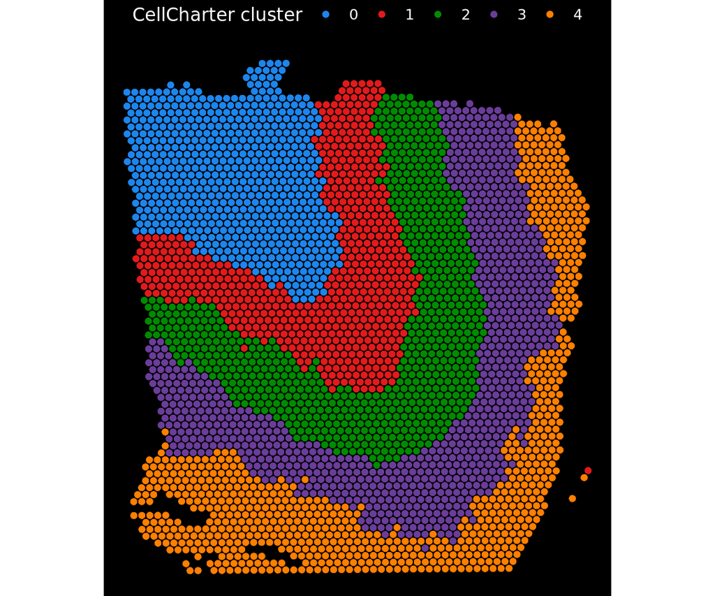

```r
data$cellcharter_clusters = as.character(data$cellcharter_clusters)
KanPlot(data, feature = 'cellcharter_clusters',pt.size=2) + labs(fill = 'CellCharter cluster')
```

# 8) Co-localisation / dispersion analysis

Kandinsky can test whether pairs of cell/spot types tend to co-localise or spatially avoid each other, using a join-count based statistic implemented in `jc_coloc()`. Positive z-values indicate co-localisation, negative values indicate dispersion:

```r
coloc = jc_coloc(data, label = 'label', return.mat = TRUE)
knitr::kable(head(coloc$coloc_mat))
```

|  | Joincount | Expected | Variance | z-value | Type1 | Type2 | oe_log2ratio | oe_ratio |
| --- | --- | --- | --- | --- | --- | --- | --- | --- |
| Layer1:Layer1 | 686 | 60.46109 | 51.94399 | 86.79340 | Layer1 | Layer1 | 3.504130 | 11.346141 |
| Layer2:Layer2 | 541 | 51.91172 | 45.11390 | 72.81688 | Layer2 | Layer2 | 3.381496 | 10.421538 |
| Layer3:Layer3 | 2734 | 795.60523 | 430.78783 | 93.39218 | Layer3 | Layer3 | 1.780889 | 3.436378 |
| Layer4:Layer4 | 457 | 38.51772 | 34.14773 | 71.61370 | Layer4 | Layer4 | 3.568600 | 11.864668 |
| Layer5:Layer5 | 1824 | 368.23811 | 247.70635 | 92.49575 | Layer5 | Layer5 | 2.308395 | 4.953317 |
| Layer6:Layer6 | 1920 | 389.33956 | 258.67294 | 95.17072 | Layer6 | Layer6 | 2.302005 | 4.931428 |

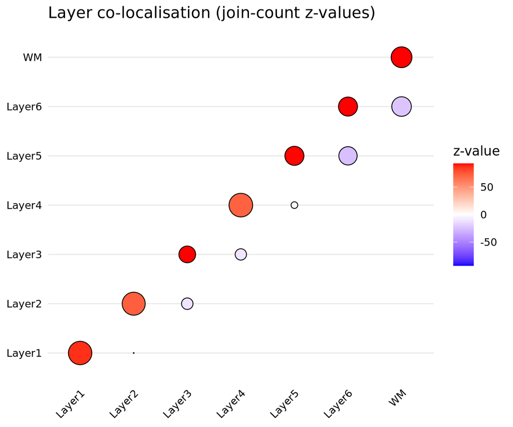

```r
coloc$plot + ggtitle('Layer co-localisation (join-count z-values)')
```

As expected for a layered tissue, each layer strongly co-localises with itself (high positive diagonal z-values), reflecting the spatial contiguity of the simulated cortical layers. Missing dots in the final colocalisation diagonal heatmap (e.g. Layer1-WM pair) reflects the complete absence of any cells/spots of two groups lying in each other’s neighbourhood.

## Alternative co-localisation methods

`jc_coloc()` is Kandinsky’s native join-count based colocalisation test, but the package also provides wrappers around widely-used external tools sharing the same `label`/`return.mat` interface and producing a comparable heatmap, useful for benchmarking:

- `hoodscanR_coloc()`: computes colocalisation from neighbourhood probability profiles using the Bioconductor package `hoodscanR` (pure R, no Python required).
- `giotto_coloc()`: cell-proximity enrichment test from the `Giotto` package.
- `squidpy_coloc()` / `cellcharter_coloc()`: neighbourhood enrichment tests from the Python packages `squidpy`/`CellCharter`, called through `reticulate` (again using `python_path = pypath`).

```r
# Requires hoodscanR to be installed
coloc_hs = hoodscanR_coloc(data, label = 'label', k=50, return.mat = TRUE)
coloc_hs$plot
```

[output not shown]

# 9) Hot and cold expression areas

Kandinsky can identify spatial **hot-spots** (locally high values) and **cold-spots** (locally low values) for any numeric feature - a gene, a protein, or a signature score - using Getis-Ord Gi* statistics via `hotspot_analysis()`. Continuing with *MOBP* (`ENSG00000168314`), we expect hot-spots in the `WM` region:

```r
data = hotspot_analysis(data, feature = 'ENSG00000168314', layer = 'data',
                         sim = 499, padj.thresh = 0.05)
table(data$ENSG00000168314_clust)
```

```
#>
#> Cold  Hot   NS
#>    0  464 3147
```

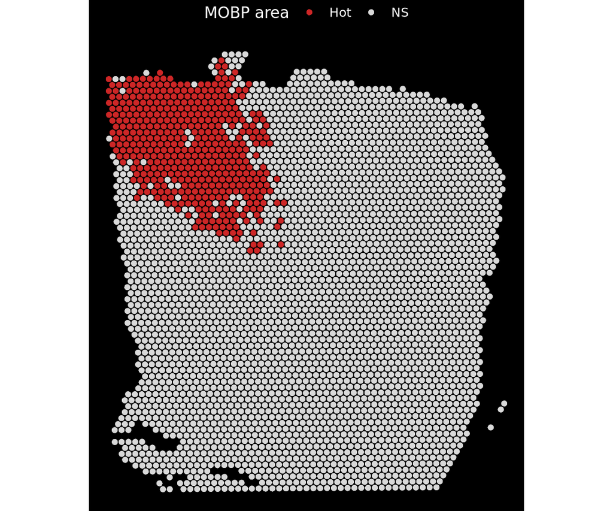

```r
KanPlot(data, feature = 'ENSG00000168314_clust',pt.size=2,
        palette_discrete = c('Cold' = 'dodgerblue3', 'Hot' = 'firebrick3', 'NS' = '#D9D9D9')) +
  labs(fill = 'MOBP area')
```

We can cross-tabulate hot/cold status against the simulated layer annotation to confirm that MOBP hot-spots are indeed concentrated in the white matter:

```r
table(data$label, data$ENSG00000168314_clust)
```

```
#>
#>          Cold Hot  NS
#>   Layer1    0   0 273
#>   Layer2    0   0 253
#>   Layer3    0   0 989
#>   Layer4    0   0 218
#>   Layer5    0   0 673
#>   Layer6    0  36 656
#>   WM        0 428  85
```

If more than one hot/cold annotation is defined within the same dataset, `hotspot_overlap()` can be used to create a combined annotation describing the overlap between the two.

# 10) Changing the neighbourhood definition

The neighbourhood definition used throughout the analysis is not fixed: it can be changed at any point using `nb_update()`. For instance, we can switch from a Delaunay definition (`soi=T`) to a centroid-distance based definition, connecting all spots within 20 distance units of each other (`nb.method = 'C'`, `d.max = 20`), corresponding to ~3 layers of surrounding spots:

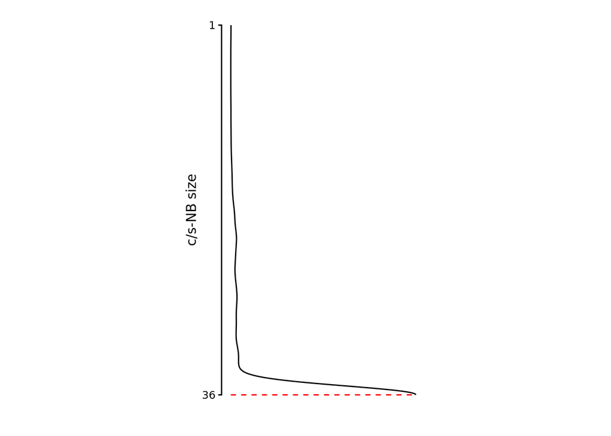

```r
data = nb_update(data, nb.method = 'C', d.max = 20)
nbSizePlot(data) + theme(aspect.ratio = 2)
```

Any downstream function relying on the neighbourhood network (`nnMat()`, `nn_query()`, `nbCluster()`, `hotspot_analysis()`, …) will now use this updated definition.

Switching to a distance-based method typically increases and unbalances neighbourhood sizes, as confirmed by `nb_summary()`, although this becomes more evident for single-cell resolution data:

```r
nb_summary(data)
```

```
#> Neighbour method: Centroid distance (C), d.max = 20
#> Total cells/spots: 3611
#> Total neighbour links: 122660
#> Minimum number of neighbours per cell/spot: 1
#> Mean number of neighbours per cell/spot: 33.97
#> Median number of neighbours per cell/spot: 36
#> Max number of neighbours per cell/spot: 36
#> Number of cells/spots with no neighbours: 0
```

# 11) Downsizing dense neighbourhoods

Distance-based neighbour definitions (`nb.method = 'C'`/`'M'`/`'Q'`) can produce very large, unevenly-sized c/s-NBs in densely packed regions of a sample, which can slow down or bias downstream analyses (e.g. `nnMat()`, `nbCluster()`). `nb_downsize()` addresses this by randomly subsampling each c/s-NB down to an expected maximum size (`exp_links`), while trying to preserve the overall network structure:

```r
data_ds = nb_downsize(data, exp_links = 6)
```

```
#> Current median number of neighbour links per cell is 36. Trying to reduce to 6...
#> Enforcing symmetric neighbourhoods...
#> Trying to trim degrees > 6...
#> Returning updated neighour network with a median number of 7 links per cell
```

```r
nb_summary(data_ds)
```

```
#> Neighbour method: Centroid distance (C), d.max = 20
#> Total cells/spots: 3611
#> Total neighbour links: 26300
#> Minimum number of neighbours per cell/spot: 1
#> Mean number of neighbours per cell/spot: 7.28
#> Median number of neighbours per cell/spot: 7
#> Max number of neighbours per cell/spot: 13
#> Number of cells/spots with no neighbours: 0
```

Neighbour relationships created with symmetric methods (`'Q'`/`'C'`/`'M'`) are, by default, kept symmetric after downsizing (`keep_symmetric = TRUE`) - meaning if spot A is downsized to keep spot B as a neighbour, spot B will also keep spot A - so some neighbourhoods may still end up slightly larger than `exp_links` after this correction. This behaviour can be disabled by setting `keep_symmetric = FALSE`.

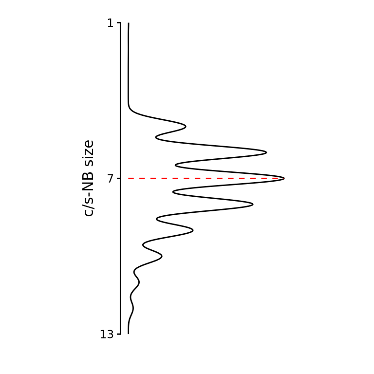

```r
nbSizePlot(data_ds) + theme(aspect.ratio = 2)
```

# Next steps

This vignette covered the core Kandinsky building blocks: initializing spatial neighbourhoods, visualizing data and tissue region masks, summarizing and querying neighbourhood composition, neighbourhood-based clustering, testing co-localisation/dispersion, detecting hot/cold expression areas, and reshaping the neighbourhood network itself (`nb_update()`, `nb_downsize()`).

Kandinsky also provides:

- platform-specific loaders (`prepare_cosmx_seurat()`, `prepare_xenium_seurat()`, `prepare_seurat_other()`, …) for CosMx, Xenium, MERSCOPE, IMC and other tabular spatial data - see the `modC`/`modD`/`modE` vignettes for full worked examples on real datasets.
- optional wrappers around external, non-native clustering (`cellcharter_clust()`, `spatialleiden_clust()`, `mesa_clust()`, `spatopic_clust()`, `hoodscanR_clust()`, `giotto_clust()`) and colocalisation (`squidpy_coloc()`, `cellcharter_coloc()`, `hoodscanR_coloc()`, `giotto_coloc()`) methods, for users who want to benchmark Kandinsky against other tools. The Python-based ones require a Python environment with the relevant dependencies installed and accessible via `reticulate` (this is what the `pypath` variable at the top of this vignette would be used for).